# HW 3

## 2.2

Notice that the above decision boundary is decidedly non-linear. It seems to perform reasonably well, but there are indeed some misclassifications. Let’s see if increasing the cost [^1] helps our classification error rate. Refit the svm with the radial kernel, $\gamma=1$, and a cost of 10000. Plot this svm on the training data.

```r
newsvmfit = svm(y~., data = train_data, kernel = "radial", cost = 10000, gamma = 1, scale = FALSE)
print(newsvmfit)
```

```
##
## Call:
## svm(formula = y ~ ., data = train_data, kernel = "radial", cost = 10000,
##     gamma = 1, scale = FALSE)
##
##
## Parameters:
##    SVM-Type:  C-classification
##  SVM-Kernel:  radial
##        cost:  10000
##
## Number of Support Vectors:  30
```

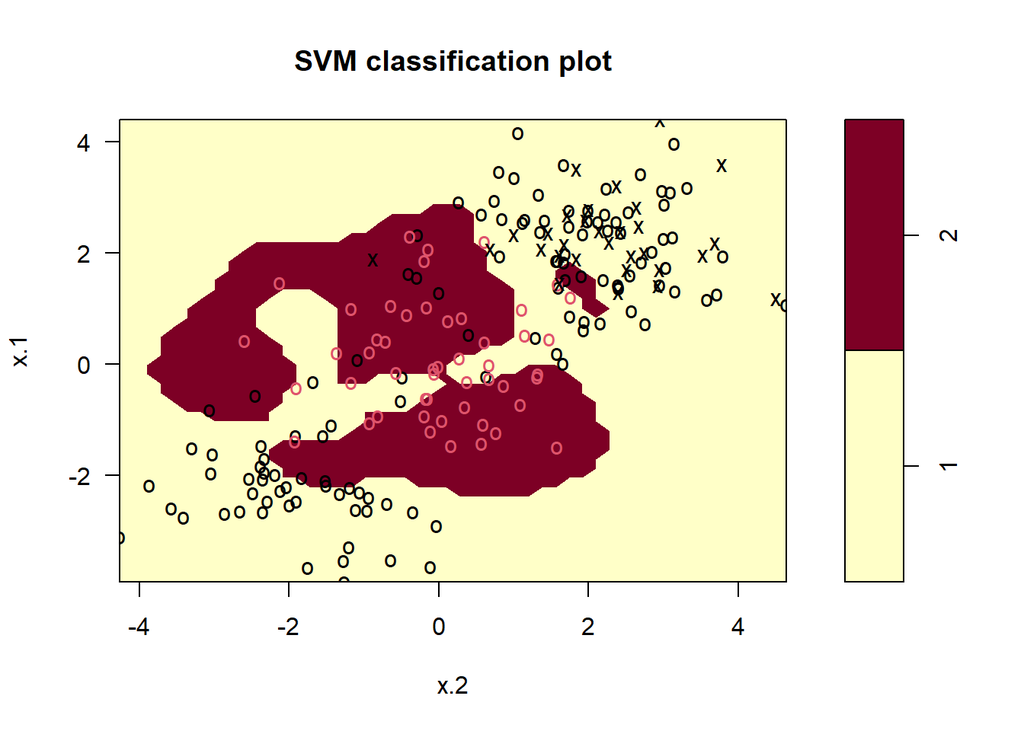

```r
plot(newsvmfit, dat)
```

## 2.3

It would appear that we are better capturing the training data, but comment on the dangers (if any exist), of such a model.

*Student Answer* Increasing the cost makes the model more accurate on the training data, but it comes at the cost of lower generalization. This means that when using this model on other data, it could perform worse. In this model, you can see that it is really fitted to the test data, which means it could break for other data.

## 2.4

Create a confusion matrix by using this svm to predict on the current testing partition. Comment on the confusion matrix. Is there any disparity in our classification results?

```r
#remove eval = FALSE in above
#table(true=dat[-train_data,"y"], pred=predict(newsvmfit, newdata=dat[-train_data,]))
#pred = predict(newsvmfit, newdata = dat[-train_index, ])

# Create a confusion matrix comparing true labels and predictions
table(true = dat[-train_index, "y"], pred = predict(newsvmfit, newdata = dat[-train_index, ]))
```

```
##     pred
## true  1  2
##    1 62 17
##    2  3 18
```

*Student Response*

It is quite accurate but there is a lot of misclassification. 17/100 were predicted to be class 2 but were actually class 1.

## 2.5

Is this disparity because of imbalance in the training/testing partition? Find the proportion of class `2` in your training partition and see if it is broadly representative of the underlying 25% of class 2 in the data as a whole.

```r
(3+18) / (62+17+3+18)
```

```
## [1] 0.21
```

*Student Response*

The disparity doesn’t seems to be because of an imbalance in training/testing partition. Here, class 2 represents 21% of the data, which is not significantly different from 25%.

## 2.6

Let’s try and balance the above to solutions via cross-validation. Using the `tune` function, pass in the training data, and a list of the following cost and $\gamma$ values: {0.1, 1, 10, 100, 1000} and {0.5, 1,2,3,4}. Save the output of this function in a variable called `tune.out`.

```r
set.seed(1)
tune.out = tune(svm, y ~ ., data = train_data,ranges = list(cost = c(0.1, 1, 10, 100, 1000),  gamma = c(0.5, 1,2,3,4)))
```

I will take `tune.out` and use the best model according to error rate to test on our data. I will report a confusion matrix corresponding to the 100 predictions.

```r
table(true=dat[-train_index,"y"], pred=predict(tune.out$best.model, newdata=dat[-train_index,]))
```

```
##     pred
## true  1  2
##    1 72  7
##    2  1 20
```

## 2.7

Comment on the confusion matrix. How have we improved upon the model in question 2 and what qualifications are still necessary for this improved model.

*Student Response* The model was improved by tuning the gamma and cost via cross-validation. The underlying dataset needs to be improved for this model to improve, since there are a lot more class 1 than class 2 values.

# 3

Let’s turn now to decision trees.

```r
library(kmed)
data(heart)
library(tree)
names(heart)
```

```
##  [1] "age"      "sex"      "cp"       "trestbps" "chol"     "fbs"
##  [7] "restecg"  "thalach"  "exang"    "oldpeak"  "slope"    "ca"
## [13] "thal"     "class"
```

```r
summary(heart)
```

```
##       age           sex          cp         trestbps          chol
##  Min.   :29.00   Mode :logical   1: 23   Min.   : 94.0   Min.   :126.0
##  1st Qu.:48.00   FALSE:96        2: 49   1st Qu.:120.0   1st Qu.:211.0
##  Median :56.00   TRUE :201       3: 83   Median :130.0   Median :243.0
##  Mean   :54.54                   4:142   Mean   :131.7   Mean   :247.4
##  3rd Qu.:61.00                           3rd Qu.:140.0   3rd Qu.:276.0
##  Max.   :77.00                           Max.   :200.0   Max.   :564.0
##     fbs          restecg    thalach        exang            oldpeak
##  Mode :logical   0:147   Min.   : 71.0   Mode :logical   Min.   :0.000
##  FALSE:254       1:  4   1st Qu.:133.0   FALSE:200       1st Qu.:0.000
##  TRUE :43        2:146   Median :153.0   TRUE :97        Median :0.800
##                          Mean   :149.6                   Mean   :1.056
##                          3rd Qu.:166.0                   3rd Qu.:1.600
##                          Max.   :202.0                   Max.   :6.200
##  slope         ca         thal        class
##  1:139   Min.   :0.0000   3:164   Min.   :0.0000
##  2:137   1st Qu.:0.0000   6: 18   1st Qu.:0.0000
##  3: 21   Median :0.0000   7:115   Median :0.0000
##          Mean   :0.6768           Mean   :0.9461
##          3rd Qu.:1.0000           3rd Qu.:2.0000
##          Max.   :3.0000           Max.   :4.0000
```

## 3.1

The response variable is currently a categorical variable with four levels. Convert heart disease into binary categorical variable. Then, ensure that it is properly stored as a factor.

```r
heart_disease <- ifelse(heart$cp == "2" | heart$cp == "1", "low", "high")
hd <- as.factor(heart_disease)
heart <- data.frame(heart, hd)
#297
```

## 3.2

Train a classification tree on a 240 observation training subset (using the seed I have set for you). Plot the tree.

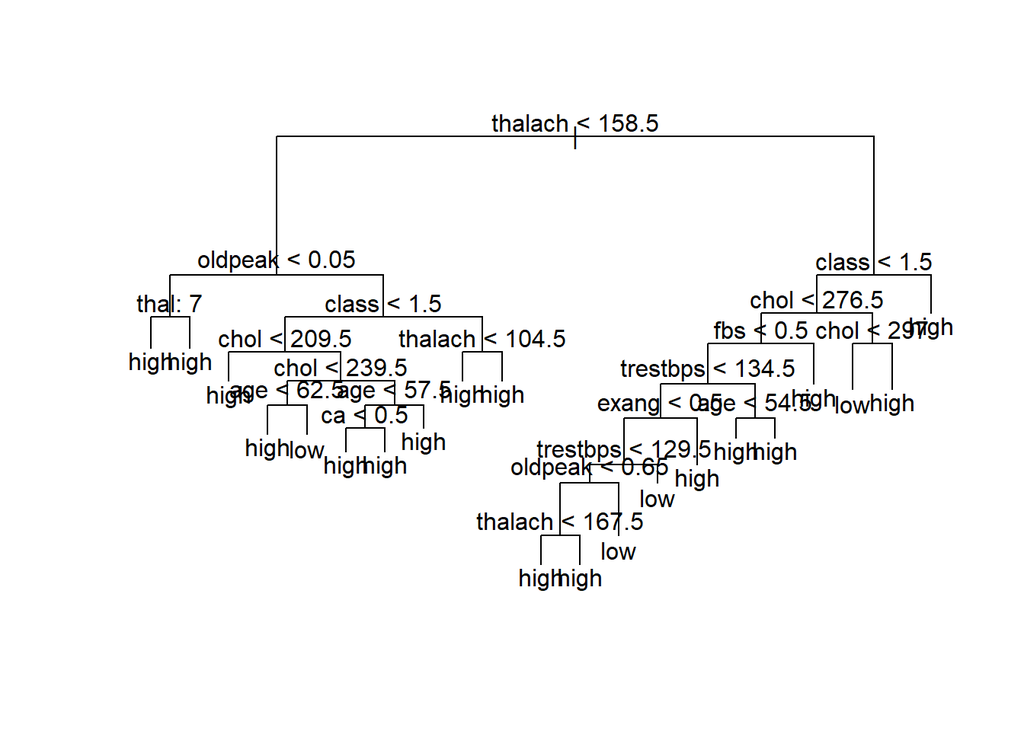

```r
set.seed(101)
train=sample(1:nrow(heart), 240)
heart_tree = tree(hd~. -cp, heart, subset = train)
plot(heart_tree)
text(heart_tree, pretty = 0)
```

## 3.3

Use the trained model to classify the remaining testing points. Create a confusion matrix to evaluate performance. Report the classification error rate.

```r
tree.pred = predict(heart_tree, heart[-train,], type="class")
#length(tree.pred)
#length(hd)
#table(tree.pred)
#table(hd)
#str(heart[-train,])
with(heart[-train,], table(tree.pred, hd))
```

```
##          hd
## tree.pred high low
##      high   37  16
##      low     3   1
```